```python
import scanpy as sc
import pandas as pd
import os
import seaborn as sns
import matplotlib.pyplot as plt
from matplotlib import colors
import numpy as np
```

```python
crc_counts = "../data/external/Zhang_Zhang_2019_CRC/smartseq2_pipeline/resultCOUNT.txt"
nsclc_counts = (
    "../data/external/Guo_Zhang_2018_NSCLC/smartseq2_pipeline/resultCOUNT.txt"
)
hcc_counts = "../data/external/Zheng_Zhang_2017_HCC/smartseq2_pipeline/resultCOUNT.txt"
crc_patient_info = "../data/external/Zhang_Zhang_2019_CRC/scripts/patient_data.tsv"
nsclc_patient_info = "../data/external/Guo_Zhang_2018_NSCLC/scripts/patient_table.tsv"
hcc_patient_info = "../data/external/Zheng_Zhang_2017_HCC//scripts/patient_table.tsv"
```

```python
# Parameters
crc_counts = "CRC/resultCOUNT.txt"
crc_patient_info = "CRC/patient_data.tsv"
hcc_counts = "HCC/resultCOUNT.txt"
hcc_patient_info = "HCC/patient_table.tsv"
nsclc_counts = "NSCLC/resultCOUNT.txt"
nsclc_patient_info = "NSCLC/patient_table.tsv"
```

# CD161 expression in external datasets

To make sure that the distribution of CD161 expression across various subtypes of CD4+ T-cells is not arising from issues of the 10x single-cell datasets, we check three publicly available Smart-seq2 datasets (CRC, NSCLC and HCC) in this notebook.

- CRC: https://www.nature.com/articles/s41597-019-0131-5#Sec36
- HCC: http://dx.doi.org/10.1016/j.cell.2017.05.035
- NSCLC: http://dx.doi.org/10.1038/s41591-018-0045-3

Raw data have been obtained from EGA under controlled access and processed using nf-core [smartseq2 pipeline](https://github.com/nf-core/smartseq2/).

```python
counts = {
    "crc": pd.read_csv(crc_counts, sep="\t", index_col=0),
    "nsclc": pd.read_csv(nsclc_counts, sep="\t", index_col=0),
    "hcc": pd.read_csv(hcc_counts, sep="\t", index_col=0),
}
```

```python
patient_info = {
    "crc": pd.read_csv(
        crc_patient_info,
        sep="\t",
        index_col="Cell name",
    ).rename({"Cell type": "sampleType"}, axis="columns"),
    "nsclc": pd.read_csv(nsclc_patient_info, sep="\t", index_col="UniqueCell_ID"),
    "hcc": pd.read_csv(hcc_patient_info, sep="\t", index_col="UniqueCell_ID"),
}
```

```python
for counts_df in counts.values():
    counts_df.columns = ["_".join(x.split("_")[2:]) for x in counts_df.columns]
```

```python
for counts_df in counts.values():
    counts_df.columns = counts_df.columns.str.replace("ZZM_", "")
```

```python
patient_info["crc"].index = patient_info["crc"].index.str.replace("P0701", "0701")
```

```python
adatas = {}
for key in ["crc", "nsclc", "hcc"]:
    counts_df = counts[key]
    patient_df = patient_info[key]
    cell_ids = list(set(counts_df.columns) & set(patient_df.index.values))
    adata = sc.AnnData(X=counts_df.loc[:, cell_ids].T, obs=patient_df.loc[cell_ids, :])
    adatas[key] = adata
```

```python
for key, adata in adatas.items():
    print(key, adata.shape)
```

```
crc (10803, 60642)
nsclc (11477, 60642)
hcc (5050, 60642)
```

```python
# os.makedirs("./tmp", exist_ok=True)
# for key, adata in adatas.items():
#     adata.write_h5ad(f"./tmp/adata_{key}.h5ad", compression='lzf')
```

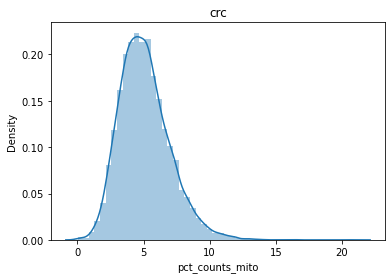

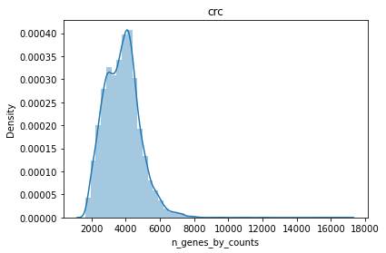

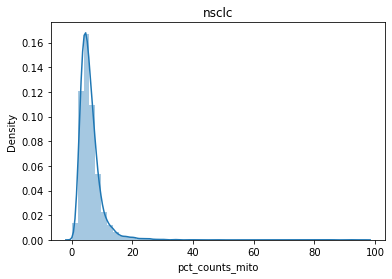

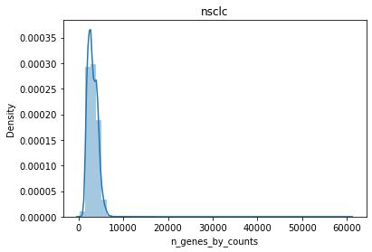

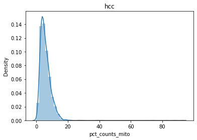

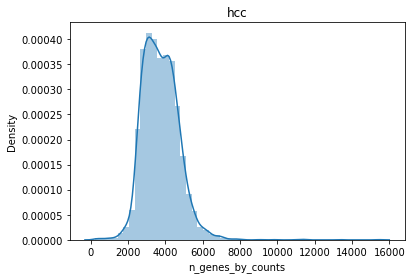

```python
for key, adata in adatas.items():
    adata.var["mito"] = adata.var_names.str.startswith("MT-")
    sc.pp.calculate_qc_metrics(adata, qc_vars=("mito",), inplace=True)
    ax = sns.distplot(adata.obs["pct_counts_mito"].dropna())
    ax.set_title(key)
    plt.show()
    ax = sns.distplot(adata.obs["n_genes_by_counts"].dropna())
    ax.set_title(key)
    plt.show()
```

```python
MIN_CELLS = 10
MAX_MITO = 16
MIN_GENES = 2000
MAX_GENES = 8000
```

```python
for key, adata in adatas.items():
    sc.pp.filter_genes(adata, min_cells=MIN_CELLS)
    sc.pp.filter_cells(adata, min_genes=MIN_GENES)
    sc.pp.filter_cells(adata, max_genes=MAX_GENES)
    adatas[key] = adata[adata.obs["pct_counts_mito"] < MAX_MITO, :]
    print(key, adatas[key].shape)
```

```
crc (10591, 41214)
```

```
nsclc (9605, 38675)
hcc (4939, 30925)
```

### Cell-types in the datasets

- PTC, CD8+ cytotoxic T cells from peripheral blood;
- TTC, CD8+ cytotoxic T cells from tumour tissue;
- NTC, CD8+ cytotoxic T cells from adjacent normal tissue
- PTH, CD4+CD25- cells from peripheral blood
- TTH, CD4+CD25- cells from tumour tissue;
- NTH, CD4+CD25- cells from adjacent normal tissue;
- PTR, CD4+CD25hi cells from peripheral blood;
- TTR, CD4+CD25hi cells from tumour tissue;
- NTR, CD4+CD25hi cells from adjacent normal tissue;
- PTY, CD4+CD25int cells from peripheral blood;
- TTY, CD4+CD25int cells from tumour tissue;
- NTY, CD4+CD25int cells from adjacent normal tissue;
- PP7, CD4+ T cells from peripheral blood;
- TP7, CD4+ T cells from tumour tissue;
- NP7, CD4+ T cells from adjacent normal tissue.

We are only interested in cells from tumor and adjacent normal tissue.

```python
# adatas_bk = {k: adata.copy() for k, adata in adatas.items()}
```

```python
# adatas = {k: adata.copy() for k, adata in adatas_bk.items()}
```

```python
for key, adata in adatas.items():
    ct_map = {"C": "CD8", "H": "CD4", "R": "Treg", "Y": "CD4", "7": "CD4"}
    adata.obs["cell_type"] = [ct_map[x[2]] for x in adata.obs["sampleType"]]
    adatas[key] = adata[
        adata.obs["sampleType"].str.startswith("T")
        | adata.obs["sampleType"].str.startswith("N"),
        :,
    ].copy()
```

```
Trying to set attribute `.obs` of view, copying.
Trying to set attribute `.obs` of view, copying.
Trying to set attribute `.obs` of view, copying.
```

```python
for key, adata in adatas.items():
    print(key)
    sc.pp.normalize_total(adata, target_sum=1000)
    sc.pp.log1p(adata)
    sc.pp.highly_variable_genes(adata, n_top_genes=3000, flavor="cell_ranger")
    adata.raw = adata
    sc.pp.combat(adata, key="Patient")
```

```
crc
```

```
Found 1 genes with zero variance.
```

```
nsclc
```

```
Found 14 genes with zero variance.
```

```
hcc
```

```
Found 3 genes with zero variance.
```

```python
for key, adata in adatas.items():
    sc.tl.pca(adata, svd_solver="arpack")
    sc.pp.neighbors(adata, n_neighbors=10, n_pcs=40)
    sc.tl.umap(adata)
```

```
crc
```

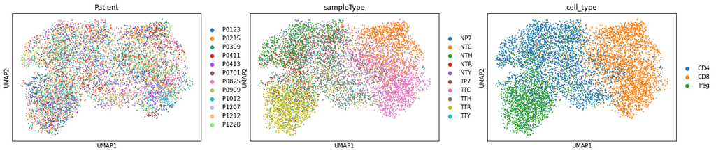

```
nsclc
```

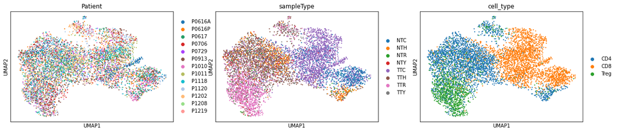

```
hcc
```

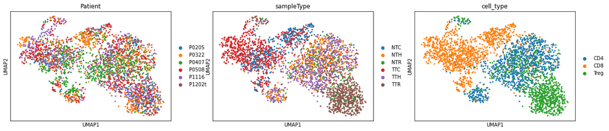

```python
for key, adata in adatas.items():
    print(key)
    sc.pl.umap(adata, color=["Patient", "sampleType", "cell_type"])
```

```python
colors2 = plt.cm.Reds(np.linspace(0, 1, 128))
colors3 = plt.cm.Greys_r(np.linspace(0.7,0.8,20))
colorsComb = np.vstack([colors3, colors2])
mymap = colors.LinearSegmentedColormap.from_list('my_colormap', colorsComb)
```

```python
def make_plots(key, **kwargs):
    adata = adatas[key]
    sc.pl.umap(
        adata, color=["cell_type", "CD8A", "CD4", "FOXP3", "KLRB1"], ncols=3, **kwargs, cmap=mymap
    )
```

## Results

The following plots show the UMAP embedding for the different cancer types. The cell-type, cell-type markers and KLRB1 are highlighted.

### NSCLC

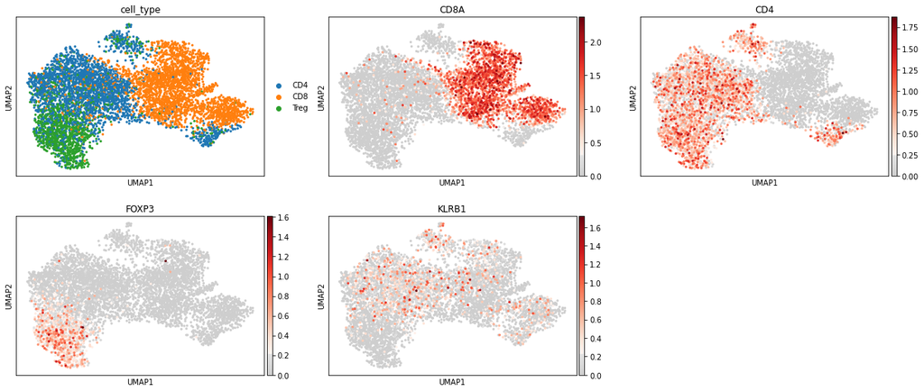

```python
make_plots("nsclc", size=40)
```

### CRC

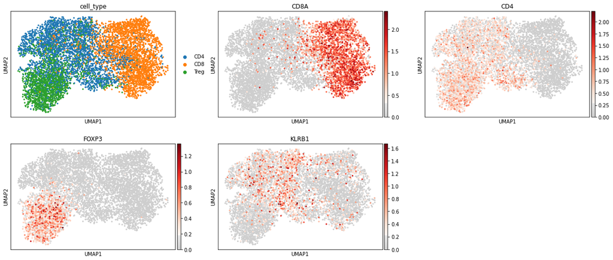

```python
make_plots("crc",  size=40)
```

### HCC

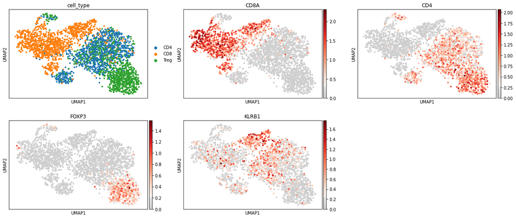

```python
make_plots("hcc", size=60)
```

### Conclusion

For all three datasets, we find that KLRB1 expression is not confined to a certain subset of CD4+ T-cells.